# R Notebook

# Apple data using SimpleTidy Workflow

Here we use another data set trying to go through the same workflow.

# Package requirement

```r
library(tidyverse)
library(ggplot2)
library(igraph)
library(ggraph)

library(readxl)
library(patchwork)
library(RColorBrewer)
library(viridis)
```

# Data resource

The data frame contains microarray gene expression data, with each row corresponding to a gene and each column representing expression levels at different time points. The data includes the mean (Mean), number of data points (n), and standard error (SE). For the 0 DAA time point, only one biological replicate was sampled. For other time points, the data is based on two biological replicates and two technical replicates. In some cases, data points were excluded for technical reasons, so the mean and standard error are only calculated based on the remaining data.

```r
dim(apple_exp)
```

```
[1] 15987    26
```

There are 15987 genes and 8 time point, DAA stands for Days After Anthesis.

```r
apple_exp %>%
  mutate(across(ends_with("Mean"), as.numeric)) %>%
  select(ends_with("Mean")) %>%
  summary()
```

```
   0 DAA Mean       14 DAA Mean        25 DAA Mean         35 DAA Mean        60 DAA Mean       87 DAA Mean       132 DAA Mean       146 DAA Mean
 Min.   : 0.0970   Min.   : 0.08612   Min.   :  0.08957   Min.   : 0.08781   Min.   : 0.1013   Min.   : 0.0738   Min.   : 0.08753   Min.   : 0.06487
 1st Qu.: 0.3528   1st Qu.: 0.36176   1st Qu.:  0.35577   1st Qu.: 0.35565   1st Qu.: 0.3618   1st Qu.: 0.3710   1st Qu.: 0.36312   1st Qu.: 0.38478
 Median : 0.6993   Median : 0.71192   Median :  0.70186   Median : 0.71305   Median : 0.7226   Median : 0.7375   Median : 0.71482   Median : 0.75483
 Mean   : 3.3384   Mean   : 3.33391   Mean   :  3.31275   Mean   : 3.44957   Mean   : 3.4013   Mean   : 3.4371   Mean   : 3.32117   Mean   : 3.36191
 3rd Qu.: 2.0028   3rd Qu.: 2.02268   3rd Qu.:  2.02592   3rd Qu.: 2.05144   3rd Qu.: 2.0625   3rd Qu.: 2.0951   3rd Qu.: 1.99989   3rd Qu.: 2.14520
 Max.   :73.1040   Max.   :95.82664   Max.   :100.00000   Max.   :73.81931   Max.   :78.6526   Max.   :61.7287   Max.   :77.80648   Max.   :68.08869
 NA's   :442       NA's   :64         NA's   :115         NA's   :196        NA's   :175       NA's   :319       NA's   :130        NA's   :193
```

Usually, when the missing values were caused by very low expression values or not detected, they were generally replaced by 0. However, according to the article, the NA part of this data frame was excluded for technical reasons, so here we employed an exclusion strategy, i.e., we did not select the genes containing the missing values for the subsequent analysis.

```r
dim(apple_exp)
```

```
[1] 15151     9
```

# PCA

[figure not shown]

```r
apple_pca = prcomp(t(apple_exp_log[, -1]))
apple_pca_imp = as.data.frame(t(summary(apple_pca)$importance))
apple_pca_coord = apple_pca$x[, 1:8] %>% # Take the all 8 PCs
  as.data.frame() %>%
  mutate(timepoint = row.names(.)) # rownames to col
apple_pca_coord
```

|  | PC1 | PC2 | PC3 | PC4 | PC5 | PC6 | PC7 | PC8 | timepoint |
| --- | --- | --- | --- | --- | --- | --- | --- | --- | --- |
| 0 DAA Mean | -4.3970338 | 7.1914525 | 7.581208 | -0.4422896 | 0.8519710 | 0.29358504 | 0.01445601 | -1.773278e-14 | 0 DAA Mean |
| 14 DAA Mean | -6.3877143 | 1.1358788 | -3.200176 | -0.8008188 | -2.1437030 | -3.64364326 | -1.73461033 | -4.866187e-14 | 14 DAA Mean |
| 25 DAA Mean | -5.6235074 | 0.3392319 | -3.519302 | 0.6803576 | -0.1028189 | 0.04431475 | 3.42564006 | -1.271419e-14 | 25 DAA Mean |
| 35 DAA Mean | -4.8272647 | -0.4801537 | -3.782964 | 0.8227913 | 1.8499954 | 3.93487445 | -1.71566123 | -2.965196e-14 | 35 DAA Mean |
| 60 DAA Mean | 0.2411714 | -7.7539167 | 3.304650 | -5.8537348 | -1.1756287 | 0.70235655 | 0.16192026 | 1.580982e-14 | 60 DAA Mean |
| 87 DAA Mean | 3.2729349 | -4.8621013 | 1.547780 | 3.8910002 | 4.0070087 | -2.32222090 | -0.13054203 | 2.686190e-14 | 87 DAA Mean |
| 132 DAA Mean | 5.9629037 | -0.7185340 | 1.434528 | 5.2810209 | -4.1793741 | 1.20060307 | -0.10405247 | 3.905683e-14 | 132 DAA Mean |
| 146 DAA Mean | 11.7585102 | 5.1481425 | -3.365724 | -3.5783268 | 0.8925495 | -0.20986970 | 0.08284973 | 7.219080e-15 | 146 DAA Mean |

According to the paper, DAA and the fruit development stage have a certain corresponding relationship:

0-35 DAA : Cell division 60-87 DAA : Starch accumulation 132-146 DA : Ripening

As we don’t have many combination of the libraries, we won’t expect a strong explanation by stage but it worth a look.

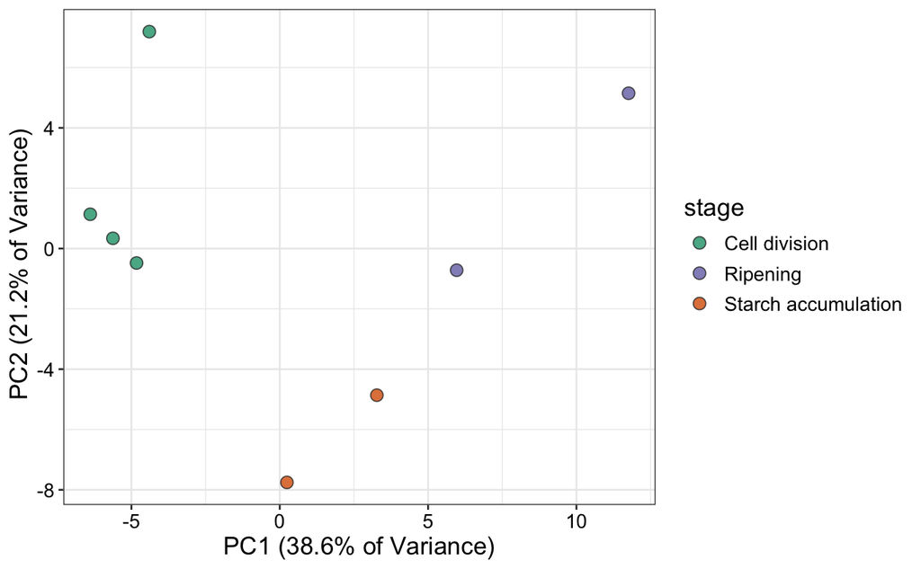

```r
# mutate a stage column
apple_pca_coord = apple_pca_coord %>%
  mutate(stage = case_when(
    timepoint %in% c("0 DAA Mean", "14 DAA Mean", "25 DAA Mean", "35 DAA Mean") ~ "Cell division",
    timepoint %in% c("60 DAA Mean", "87 DAA Mean") ~ "Starch accumulation",
    timepoint %in% c("132 DAA Mean", "146 DAA Mean") ~ "Ripening",
    TRUE ~ "Unknown"
  )) %>%
  mutate(timepoint = str_replace(timepoint, " Mean", "")) # Remove the "Mean" word in timepoint col

apple_pca_coord %>%
  ggplot(aes(x = PC1, y = PC2)) +
  geom_point(aes(fill = stage), color = "grey20", shape = 21, size = 3, alpha = 0.8) +
   scale_fill_manual(values = c("Cell division" = "#1b9e77", "Starch accumulation" = "#d95f02", "Ripening" = "#7570b3")) +
  labs(x = paste("PC1 (", apple_pca_imp[1, 2] %>% signif(3)*100, "% of Variance)", sep = ""),
       y = paste("PC2 (", apple_pca_imp[2, 2] %>% signif(3)*100, "% of Variance)", "  ", sep = ""),
       fill = "stage") +
  theme_bw() +
  theme(
    text = element_text(size= 14),
    axis.text = element_text(color = "black")
  )
```

# Bait gene

> Leave blank for now.

# Duplicated genes

```r
apple_exp_log %>%
  dim()
```

```
[1] 15151     9
```

```r
apple_exp_log %>%
  distinct(`Genbank number`) %>%
  dim()
```

```
[1] 14902     1
```

We notice that 15151 > 14902. There must be duplicated combination:

The reason for this “duplication” is that we deleted the ESTs (Expressed Sequence Tags) column at the beginning of the data processing and used the Genbank number as the gene identification.

This may represent different fragments or transcripts of the same gene. We should alter based on the gene identification to differentiate them.

```r
apple_exp_log = apple_exp_log %>%
  group_by(`Genbank number`) %>%
  mutate(gene = case_when( # mutate a new col
    n() > 1 ~ paste0(`Genbank number`, "_", row_number()), # "duplicates" will have more than 1 row. Add a symbol.
    TRUE ~ `Genbank number` # keep the same for those not_duplicated
  )) %>%
  ungroup() # %>%
  # filter(gene != `Genbank number`) # how to check for the altered rows
```

# Gene selection

```r
# long version
apple_exp_log_long = apple_exp_log %>%
  rename_with(~ gsub(" Mean", "", .), contains("DAA")) %>% # Remove the "Mean" in colnames
  pivot_longer(
    cols = starts_with("0 DAA"):starts_with("146 DAA"),
    names_to = "timepoint",
    values_to = "log_exp"
  )
```

As we know, the number of correlations scales to the square of number of genes. In order to calculate gene correlation between each other, 15000+ genes are too much. We can select only the high variance genes, as a gene is unlikely to be involved in a particular stage if it’s expressed at a similar level across all timepoints.

```r
# Calculate the rank
apple_var_rank = apple_exp_log_long %>%
  group_by(gene) %>%
  summarise(var = var(log_exp)) %>% # calculate the variance for each gene
  ungroup() %>%
  mutate(rank = rank(var, ties.method = "average")) # rank the genes

head(apple_var_rank)
```

| gene | var | rank |
| --- | --- | --- |
| A00196_1 | 0.0005931426 | 3848 |
| A00196_2 | 0.0024376608 | 8027 |
| AF078810_1 | 0.0024318226 | 8015 |
| AF078810_2 | 0.0017649853 | 7011 |
| AF126021_1 | 0.0028813476 | 8598 |
| AF126021_10 | 0.0002858044 | 2078 |

```r
# If we take the top 1/3 of the highest variance genes
high_var_apple = apple_exp_log_long %>%
  group_by(gene) %>%
  summarise(var = var(log_exp)) %>%
  ungroup() %>%
  filter(var > quantile(var, 0.667))

# And take the top 3000
high_var_apple3000 = high_var_apple %>%
  slice_max(order_by = var, n = 3000)
```

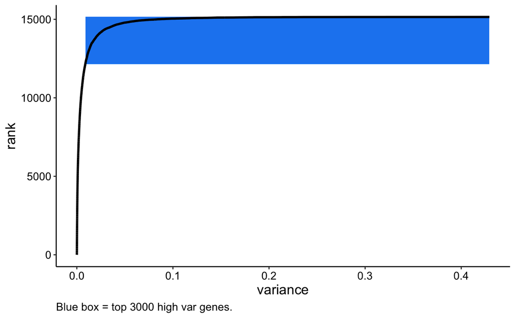

```r
# Check whether top 3000 can represent the genes of highest variance
apple_var_rank %>%
  ggplot(aes(x = var, y = rank)) +
   geom_rect(
    xmax = max(high_var_apple3000$var),
    xmin = min(high_var_apple3000$var),
    ymax = nrow(apple_var_rank),
    ymin = nrow(apple_var_rank) - 3000,
    fill = "dodgerblue2", alpha = 0.2
    ) +
  geom_line(size = 1.1) +
  labs(y = "rank",
       x = "variance",
       caption = "Blue box = top 3000 high var genes.") +
  theme_classic() +
  theme(
    text = element_text(size = 14),
    axis.text = element_text(color = "black"),
    plot.caption = element_text(hjust = 0)
  )
```

It looks like if we take the top 3000 genes, it takes pretty much the entire upper elbow of the graph.

> Add vertical line to verify after select the bait genes

```r
# Select high var gene
apple_exp_log_highvar = apple_exp_log_long %>%
  filter(gene %in% high_var_apple3000$gene)
dim(apple_exp_log_highvar)
```

```
[1] 24000     4
```